# Week 6 Homework

Brandon Güell

10/19/2017

1: Write a simple R function, Z.prop.test(), that can perform one- or two-sample Z-tests for proportion data, using the following guidelines

```r
z.prop.test <- function(p1, n1, p2 = NULL, n2 = NULL, p0, alternative = "two.sided", conf.level =0.95)
{

  OK <- complete.cases(p1, n1, p0)
    p1 <- p1[OK]
    n1 <- n1[OK]
    p0 <- p0[OK]


    if (n1*p1 < 5)
    warning("assumption is not met")
    if (n1 * (1-p1) < 5)
  warning("assumption is not met")


    if (is.null(c(p2,n2))) {
      z <- (p1-p0)/sqrt((p0 * (1-p0)/n1))
    lower <- p1 - qnorm(0.975) * sqrt(p1 * (1 - p1)/n1)
    upper <- p1 + qnorm(0.975) * sqrt(p1 * (1 - p1)/n1)
    ci <- c(lower, upper)

        if (alternative == "less") {
            p <- pnorm(z, lower.tail = TRUE)
        }
        if (alternative == "greater") {
            p <- pnorm(z, lower.tail = FALSE)
        }
        if (alternative == "two.sided") {
            if (z > 0)
                {
                  p <- 2 * pnorm(z, lower.tail = FALSE)
                }
            if (z < 0)
                {
                  p <- 2 * pnorm(z, lower.tail = TRUE)
                }

        }
    }

    #SECOND PART STARTS HERE FOR TWO-SAMPLE
   else  {
     pstar= p1+p2
     pci= p2-p1
     ntot= n1 + n2
      z <- (p2 - p1)/sqrt((pstar * (1 - pstar)) * (1/n1) + 1/n2)

    lower <- pci - qnorm(0.975) * sqrt(pci * (1 - pci)/ntot)
    upper <- pci + qnorm(0.975) * sqrt(pci * (1 - pci)/ntot)
    ci <- c(lower, upper)

        if (alternative == "less") {
            p <- pnorm(z, lower.tail = TRUE)
        }
        if (alternative == "greater") {
            p <- pnorm(z, lower.tail = FALSE)
        }
        if (alternative == "two.sided") {
            if (z > 0)
                {
                  p <- 2 * pnorm(z, lower.tail = FALSE)
                }
            if (z < 0)
                {
                  p <- 2 * pnorm(z, lower.tail = TRUE)
                }

        }
    }



  spitout <- list(statistic = z,
         p.value = p,
         conf.int = ci,
         alternative = alternative)

    return(spitout)
  }
```

2: The dataset from Kamilar and Cooper has in it a large number of variables related to life history and body size. For this exercise, the end aim is to fit a simple linear regression model to predict longevity (MaxLongevity_m) measured in months from species’ brain size (Brain_Size_Species_Mean) measured in grams. Do the following for both longevity~brain size and log(longevity)~log(brain size).

First for longevity~brain size

```r
library(curl)
library(ggplot2)

f <- curl("https://raw.githubusercontent.com/fuzzyatelin/fuzzyatelin.github.io/master/AN597_Fall17/KamilarAndCooperData.csv")
d <- read.csv(f, header = TRUE, sep = ",", stringsAsFactors = FALSE)
head(d)
```

```
##               Scientific_Name          Family          Genus      Species
## 1 Allenopithecus_nigroviridis Cercopithecidae Allenopithecus nigroviridis
## 2         Allocebus_trichotis Cercopithecidae      Allocebus    trichotis
## 3           Alouatta_belzebul        Atelidae       Alouatta     belzebul
## 4             Alouatta_caraya        Atelidae       Alouatta       caraya
## 5            Alouatta_guariba        Atelidae       Alouatta      guariba
## 6           Alouatta_palliata        Atelidae       Alouatta     palliata
##   Brain_Size_Species_Mean Brain_Size_Female_Mean   Brain_size_Ref
## 1                   58.02                  53.70 Isler et al 2008
## 2                      NA                     NA
## 3                   52.84                  51.19 Isler et al 2008
## 4                   52.63                  47.80 Isler et al 2008
## 5                   51.70                  49.08 Isler et al 2008
## 6                   49.88                  48.04 Isler et al 2008
##   Body_mass_male_mean Body_mass_female_mean Mass_Dimorphism
```

[output cut: 69 more lines]

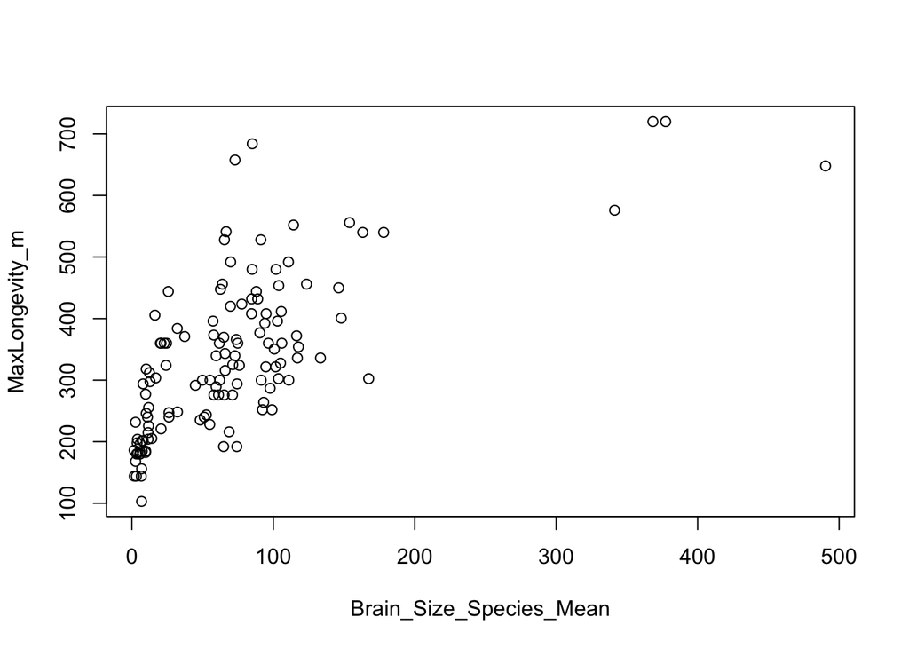

```r
#first for logevity~brain size
plot(data=d, MaxLongevity_m~Brain_Size_Species_Mean)
```

```r
m= lm(data=d, MaxLongevity_m~Brain_Size_Species_Mean)
m
```

```
##
## Call:
## lm(formula = MaxLongevity_m ~ Brain_Size_Species_Mean, data = d)
##
## Coefficients:
##             (Intercept)  Brain_Size_Species_Mean
##                 248.952                    1.218
```

```r
#Here B1== 1.218 and B0== 248.952
summary(m)
```

```
##
## Call:
## lm(formula = MaxLongevity_m ~ Brain_Size_Species_Mean, data = d)
##
## Residuals:
##     Min      1Q  Median      3Q     Max
## -198.27  -61.92  -17.78   56.16  331.36
##
## Coefficients:
##                         Estimate Std. Error t value Pr(>|t|)
## (Intercept)             248.9523    11.1111   22.41   <2e-16 ***
## Brain_Size_Species_Mean   1.2180     0.1101   11.06   <2e-16 ***
## ---
## Signif. codes:  0 '***' 0.001 '**' 0.01 '*' 0.05 '.' 0.1 ' ' 1
##
## Residual standard error: 90.91 on 126 degrees of freedom
##   (85 observations deleted due to missingness)
## Multiple R-squared:  0.4928, Adjusted R-squared:  0.4887
## F-statistic: 122.4 on 1 and 126 DF,  p-value: < 2.2e-16
```

```r
ci = confint(m, level = 0.90)
ci
```

```
##                                5 %      95 %
## (Intercept)             230.540738 267.36379
## Brain_Size_Species_Mean   1.035571   1.40041
```

[figure not shown]

```r
# ci ==  1.035571 & 1.40041

g= ggplot(data = d, aes(x=log(Brain_Size_Species_Mean), y=MaxLongevity_m)) + geom_point() + geom_smooth(method = "lm", formula = y ~ x) + annotate("text", x = 4, y = 25, label = "y = 1.218x + 248.952")
g
```

Here I begin to write code for the CI and Prediction Intervals:

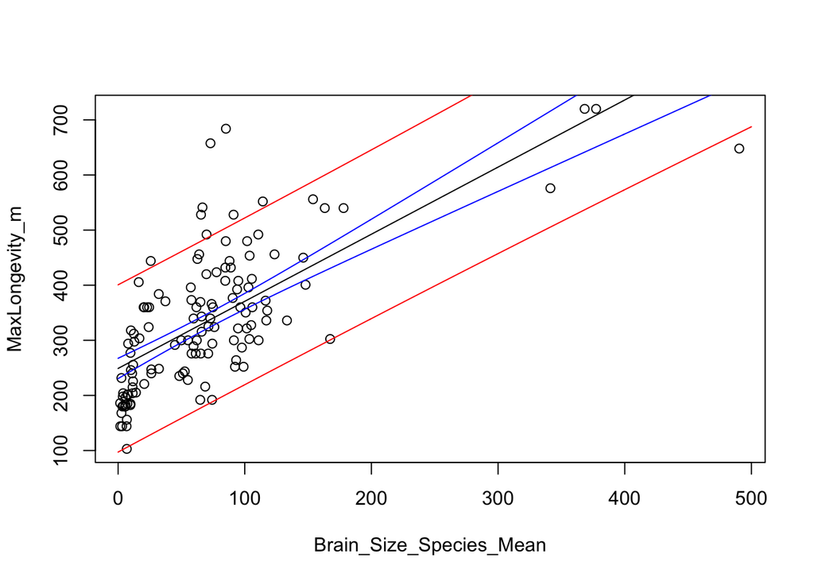

```r
v = seq(from = 0, to = 500, by = 1)
m = lm(data=d, MaxLongevity_m~Brain_Size_Species_Mean)
ci = predict(m, newdata = data.frame(Brain_Size_Species_Mean = v), interval = "confidence", level = 0.90)
pi = predict(m, newdata = data.frame(Brain_Size_Species_Mean = v), interval = "prediction", level = 0.90)

plot(data = d,MaxLongevity_m ~ Brain_Size_Species_Mean)
lines(x = v, y = ci[, 1], col = "black")
lines(x = v, y = ci[, 2], col = "blue")
lines(x = v, y = ci[, 3], col = "blue")
lines(x = v, y = pi[, 2], col = "red")
lines(x = v, y = pi[, 3], col = "red")
```

```r
df <- data.frame(cbind(v, ci, pi))
names(df) <- c("Brain_Size_Species_Mean", "CIfit", "CIlwr", "CIupr", "PIfit", "PIlwr", "PIupr")
head(df)
```

```
##   Brain_Size_Species_Mean    CIfit    CIlwr    CIupr    PIfit     PIlwr
## 1                       0 248.9523 230.5407 267.3638 248.9523  97.18861
## 2                       1 250.1703 231.8842 268.4563 250.1703  98.42177
## 3                       2 251.3882 233.2268 269.5497 251.3882  99.65472
## 4                       3 252.6062 234.5683 270.6441 252.6062 100.88745
## 5                       4 253.8242 235.9089 271.7396 253.8242 102.11996
## 6                       5 255.0422 237.2484 272.8360 255.0422 103.35226
##      PIupr
## 1 400.7159
## 2 401.9187
## 3 403.1218
## 4 404.3250
## 5 405.5285
## 6 406.7322
```

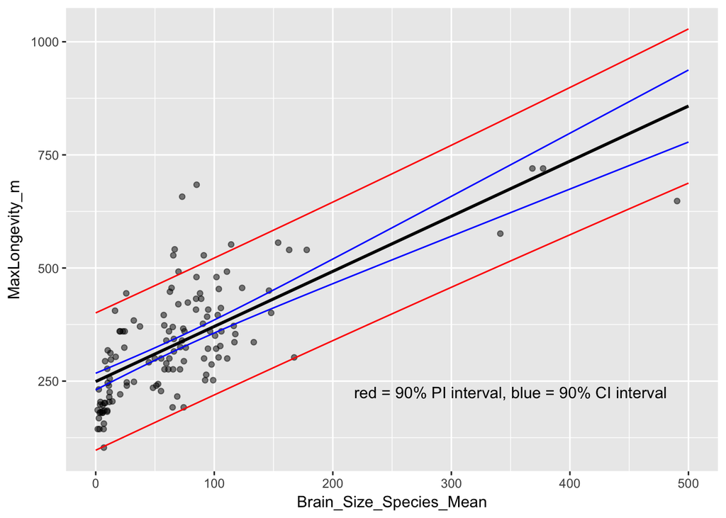

```r
g1 <- ggplot(data = d, aes(x = Brain_Size_Species_Mean, y = MaxLongevity_m))
g1 <- g1 + geom_point(alpha = 1/2)
g1 <- g1 + geom_line(data = df, aes(x = v, y = CIfit), colour = "black", lwd = 1)
g1 <- g1 + geom_line(data = df, aes(x = v, y = CIlwr), colour = "blue")
g1 <- g1 + geom_line(data = df, aes(x = v, y = CIupr), colour = "blue")
g1 <- g1 + geom_line(data = df, aes(x = v, y = PIlwr), colour = "red")
g1 <- g1 + geom_line(data = df, aes(x = v, y = PIupr), colour = "red")

g1 = g1 + annotate("text", x = 350, y = 225, label = "red = 90% PI interval, blue = 90% CI interval")
g1
```

Here I predict the 90 percent PI for the longevity of a species whose brain weight is 800 gm.

```r
ppi <- predict(m, newdata = data.frame(Brain_Size_Species_Mean = 800), interval = "prediction", level = 0.90)  # for a single value
ppi
```

```
##        fit      lwr      upr
## 1 1223.345 1021.805 1424.884
```

I somewhat trust this model but not much because the r squared value is quite low at .48 which means less than 50% of the variation in max longevity is explained by brain size species mean. Also hte prediction intervals are quite large.

# Starting it all again for the log(longevity)~log(brain size)

```r
library(curl)
library(ggplot2)

f <- curl("https://raw.githubusercontent.com/fuzzyatelin/fuzzyatelin.github.io/master/AN597_Fall17/KamilarAndCooperData.csv")
d <- read.csv(f, header = TRUE, sep = ",", stringsAsFactors = FALSE)
head(d)
```

```
##               Scientific_Name          Family          Genus      Species
## 1 Allenopithecus_nigroviridis Cercopithecidae Allenopithecus nigroviridis
## 2         Allocebus_trichotis Cercopithecidae      Allocebus    trichotis
## 3           Alouatta_belzebul        Atelidae       Alouatta     belzebul
## 4             Alouatta_caraya        Atelidae       Alouatta       caraya
## 5            Alouatta_guariba        Atelidae       Alouatta      guariba
## 6           Alouatta_palliata        Atelidae       Alouatta     palliata
##   Brain_Size_Species_Mean Brain_Size_Female_Mean   Brain_size_Ref
## 1                   58.02                  53.70 Isler et al 2008
## 2                      NA                     NA
## 3                   52.84                  51.19 Isler et al 2008
## 4                   52.63                  47.80 Isler et al 2008
## 5                   51.70                  49.08 Isler et al 2008
## 6                   49.88                  48.04 Isler et al 2008
##   Body_mass_male_mean Body_mass_female_mean Mass_Dimorphism
```

[output cut: 69 more lines]

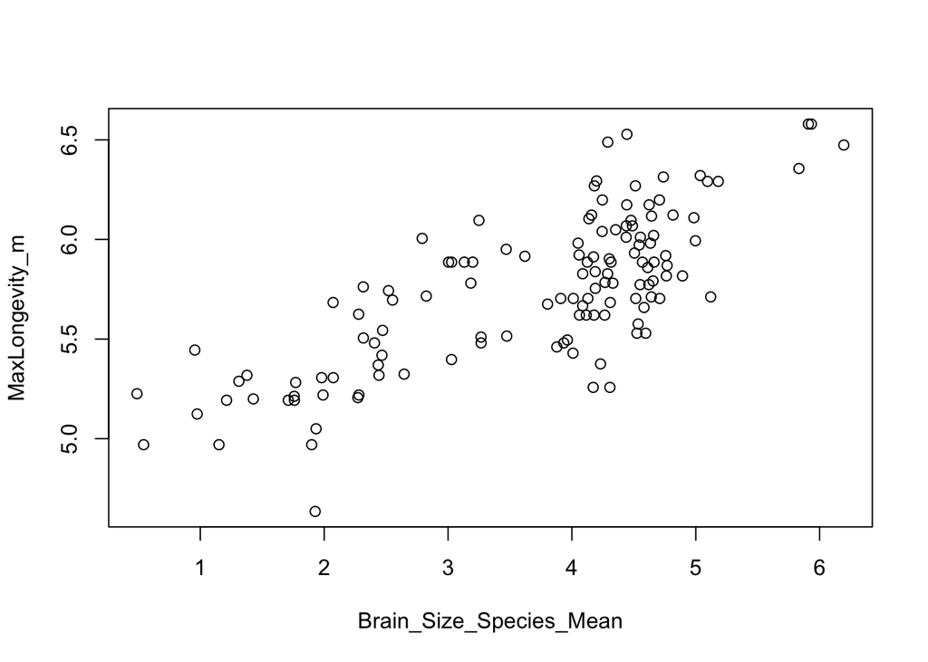

```r
d$MaxLongevity_m=log(d$MaxLongevity_m)
d$Brain_Size_Species_Mean=log(d$Brain_Size_Species_Mean)
#first for logevity~brain size
plot(data=d, MaxLongevity_m~Brain_Size_Species_Mean)
```

```r
m= lm(data=d, MaxLongevity_m~Brain_Size_Species_Mean)
m
```

```
##
## Call:
## lm(formula = MaxLongevity_m ~ Brain_Size_Species_Mean, data = d)
##
## Coefficients:
##             (Intercept)  Brain_Size_Species_Mean
##                  4.8790                   0.2341
```

```r
#Here B1== 0.2341 and B0== 4.8790
summary(m)
```

```
##
## Call:
## lm(formula = MaxLongevity_m ~ Brain_Size_Species_Mean, data = d)
##
## Residuals:
##     Min      1Q  Median      3Q     Max
## -0.6955 -0.1750 -0.0097  0.1788  0.6084
##
## Coefficients:
##                         Estimate Std. Error t value Pr(>|t|)
## (Intercept)              4.87895    0.06907   70.63   <2e-16 ***
## Brain_Size_Species_Mean  0.23415    0.01781   13.15   <2e-16 ***
## ---
## Signif. codes:  0 '***' 0.001 '**' 0.01 '*' 0.05 '.' 0.1 ' ' 1
##
## Residual standard error: 0.2485 on 126 degrees of freedom
##   (85 observations deleted due to missingness)
## Multiple R-squared:  0.5784, Adjusted R-squared:  0.5751
## F-statistic: 172.9 on 1 and 126 DF,  p-value: < 2.2e-16
```

```r
ci = confint(m, level = 0.90)
ci
```

```
##                               5 %      95 %
## (Intercept)             4.7644934 4.9934084
## Brain_Size_Species_Mean 0.2046396 0.2636595
```

[figure not shown]

```r
# ci == 0.2046396 & 0.2636595

g= ggplot(data = d, aes(x=Brain_Size_Species_Mean, y=MaxLongevity_m)) + geom_point() + geom_smooth(method = "lm", formula = y~x) + annotate("text", x = 4, y = 4.5, label = "y = 1.218x + 248.952")
g
```

Here I begin to write code for the CI and Prediction Intervals:

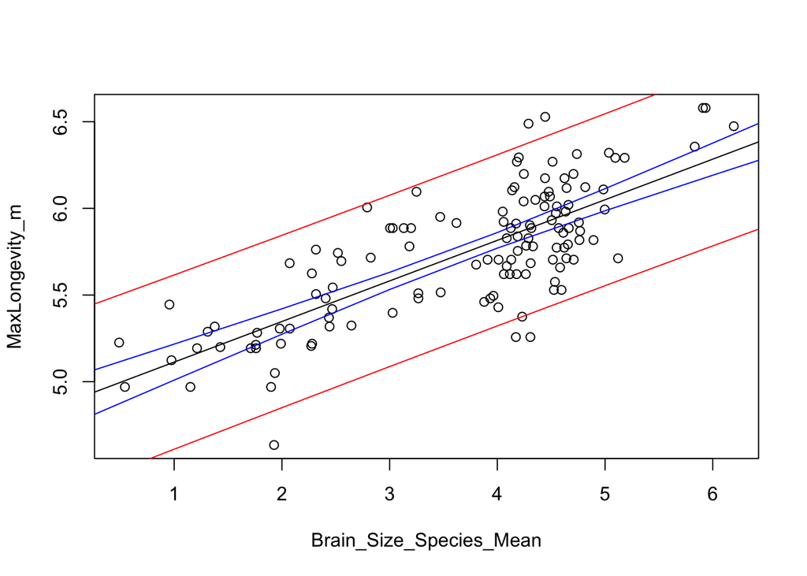

```r
v = seq(from = 0, to = 7, by = 1)
m = lm(data=d, MaxLongevity_m~Brain_Size_Species_Mean)
ci = predict(m, newdata = data.frame(Brain_Size_Species_Mean = v), interval = "confidence", level = 0.95)
pi = predict(m, newdata = data.frame(Brain_Size_Species_Mean = v), interval = "prediction", level = 0.95)

plot(data = d, MaxLongevity_m ~ Brain_Size_Species_Mean)
lines(x = v, y = ci[, 1], col = "black")
lines(x = v, y = ci[, 2], col = "blue")
lines(x = v, y = ci[, 3], col = "blue")
lines(x = v, y = pi[, 2], col = "red")
lines(x = v, y = pi[, 3], col = "red")
```

```r
df <- data.frame(cbind(v, ci, pi))
names(df) <- c("Brain_Size_Species_Mean", "CIfit", "CIlwr", "CIupr", "PIfit", "PIlwr", "PIupr")
head(df)
```

```
##   Brain_Size_Species_Mean    CIfit    CIlwr    CIupr    PIfit    PIlwr
## 1                       0 4.878951 4.742256 5.015646 4.878951 4.368616
## 2                       1 5.113101 5.009214 5.216987 5.113101 4.610559
## 3                       2 5.347250 5.273879 5.420622 5.347250 4.850119
## 4                       3 5.581400 5.531815 5.630984 5.581400 5.087219
## 5                       4 5.815549 5.770627 5.860472 5.815549 5.321815
## 6                       5 6.049699 5.985968 6.113429 6.049699 5.553899
##      PIupr
## 1 5.389285
## 2 5.615642
## 3 5.844381
## 4 6.075580
## 5 6.309284
## 6 6.545499
```

[figure not shown]

```r
g1 <- ggplot(data = d, aes(x = Brain_Size_Species_Mean, y = MaxLongevity_m))
g1 <- g1 + geom_point(alpha = 1/2)
g1 <- g1 + geom_line(data = df, aes(x = v, y = CIfit), colour = "black", lwd = 1)
g1 <- g1 + geom_line(data = df, aes(x = v, y = CIlwr), colour = "blue")
g1 <- g1 + geom_line(data = df, aes(x = v, y = CIupr), colour = "blue")
g1 <- g1 + geom_line(data = df, aes(x = v, y = PIlwr), colour = "red")
g1 <- g1 + geom_line(data = df, aes(x = v, y = PIupr), colour = "red")

g1 = g1 + annotate("text", x = 4, y = 4, label = "red = 90% PI interval, blue = 90% CI interval")
g1
```

```r
ppi <- predict(m, newdata = data.frame(Brain_Size_Species_Mean = 800), interval = "prediction", level = 0.90)  # for a single value
ppi
```

```
##        fit      lwr      upr
## 1 192.1986 168.6955 215.7017
```